# Horsetooth Reservoir Lab Final Report

# Results

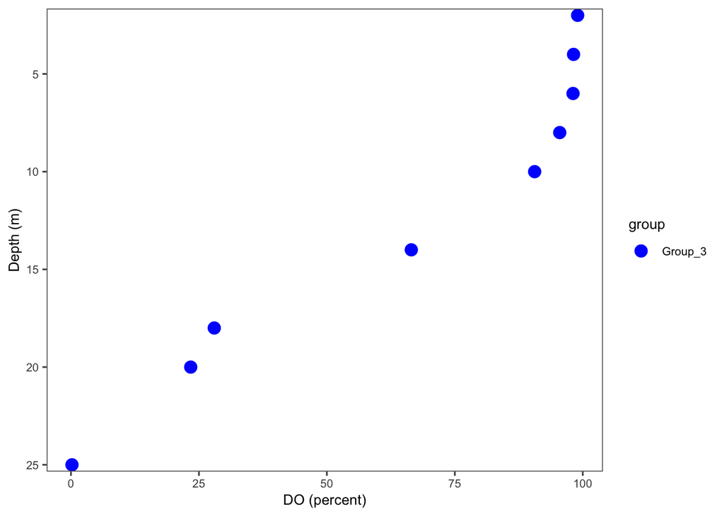

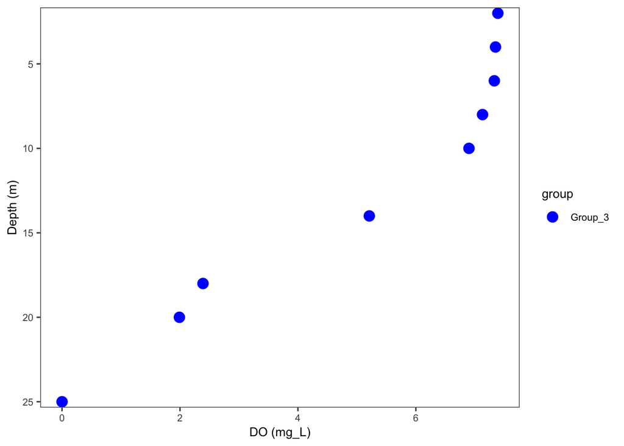

Figure 2: Group 3-Depth Profiles for Horsetooth Reservoir Dissolved Oxygen-Surveyed 9/9/2024 (Mg/L and Percentage)

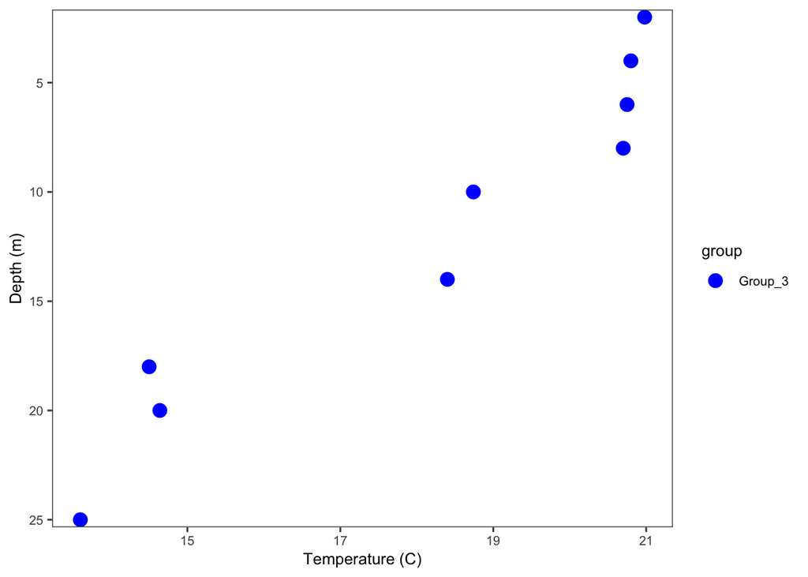

Figure 3: Temperature Profile of Horsetooth Reservoir - Surveyed 9/9/2024

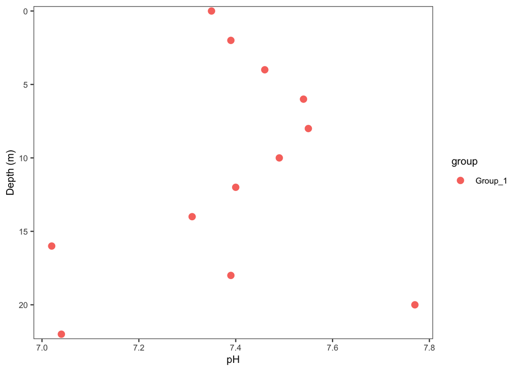

Figure 4: pH-Depth Profile of Horsetooth Reservoir - Surveyed 9/9/2024

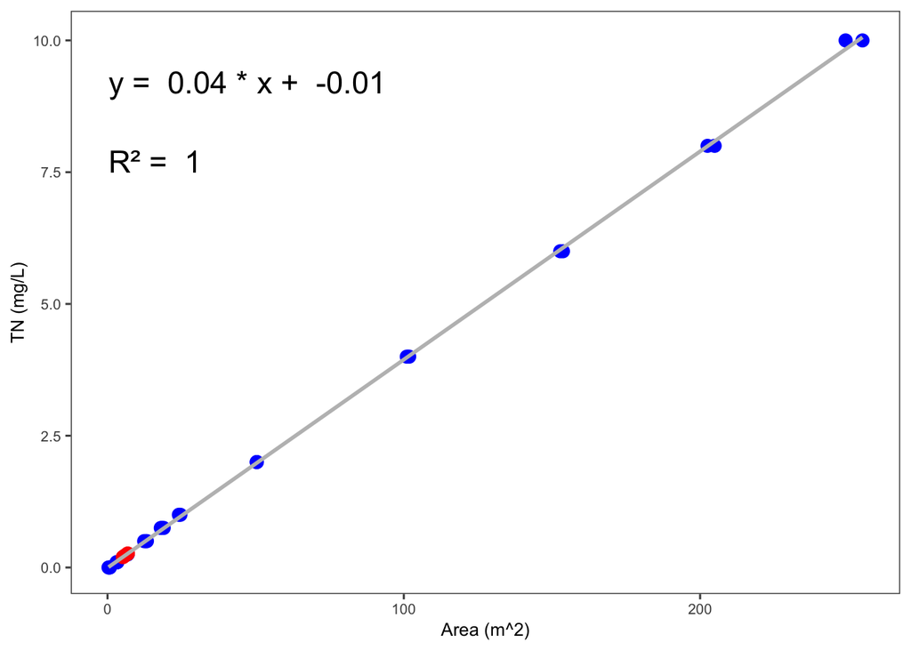

Figure 5. Total nitrogen standard curve of Horsetooth Reservoir - Surveyed 9/9/2024

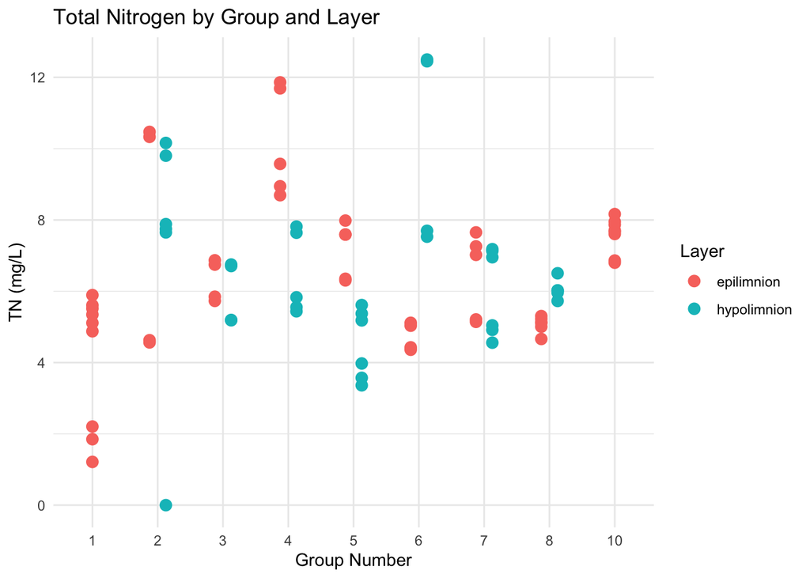

Figure 6: Comparison of total nitrogen values taken by each group at Horsetooth Reservoir - Surveyed 9/9/2024

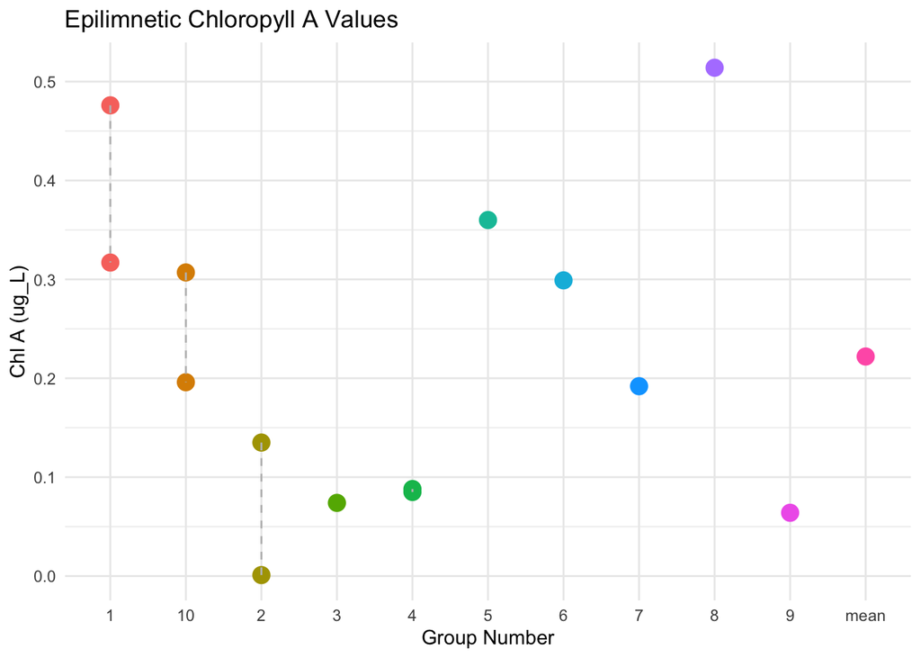

Figure 7: Comparison of chlorophyll A values taken by each group and the average of all values at Horsetooth Reservoir - Surveyed 9/9/2024

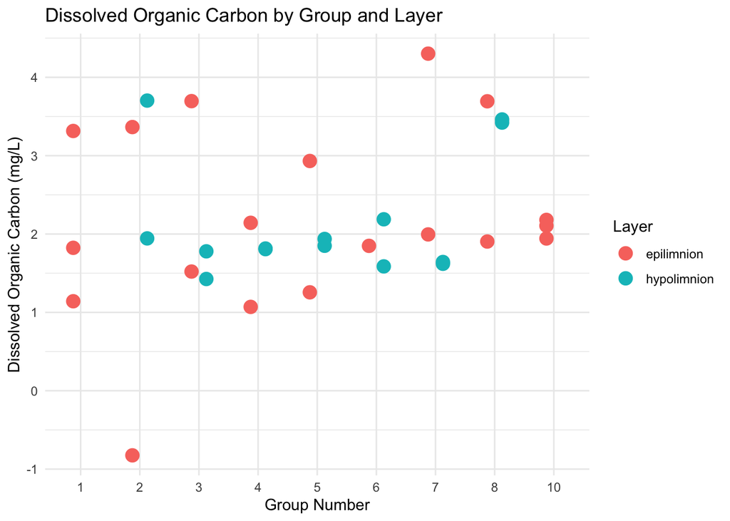

Figure 8: Comparison of dissolved organic carbon (mg/L) values between the epilimnion and hypolimnion taken by each group at Horsetooth Reservoir - Surveyed 9/9/2024

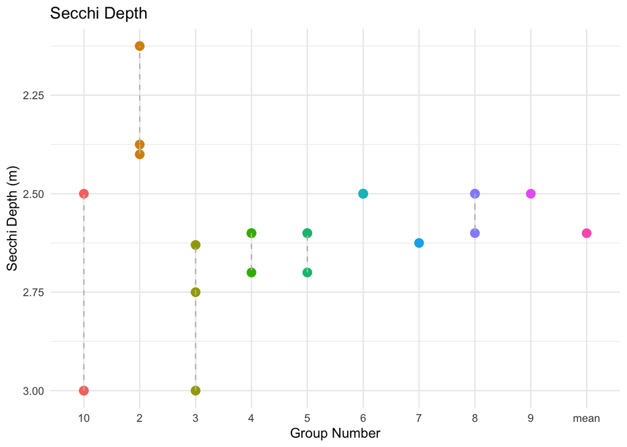

Figure 9: Comparison of secchi depths taken by each group and the average of all depths at Horsetooth Reservoir - Surveyed 9/9/2024